# Environment Setup

```
RX1 - ADF Statistic: -20.92416552817478
RX1 - p-value: 0.0
Critical Values:
   1%: -3.4396995339981444
   5%: -2.8656659438580796
   10%: -2.5689671530263554
The time series for RX1 appears to be stationary (reject the null hypothesis of non-stationarity).
```

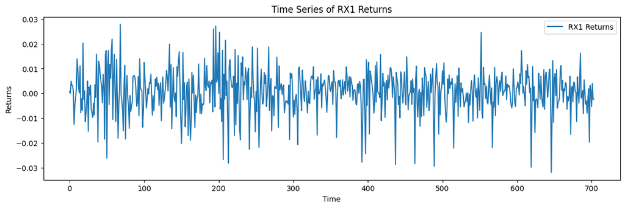

```
TY1 - ADF Statistic: -27.29090569348283
TY1 - p-value: 0.0
Critical Values:
   1%: -3.4396861854831964
   5%: -2.865660062273053
   10%: -2.5689640195342456
The time series for TY1 appears to be stationary (reject the null hypothesis of non-stationarity).
```

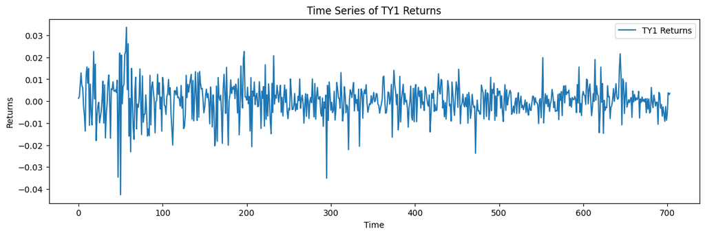

```
GC1 - ADF Statistic: -28.042888164648907
GC1 - p-value: 0.0
Critical Values:
   1%: -3.4396861854831964
   5%: -2.865660062273053
   10%: -2.5689640195342456
The time series for GC1 appears to be stationary (reject the null hypothesis of non-stationarity).
```

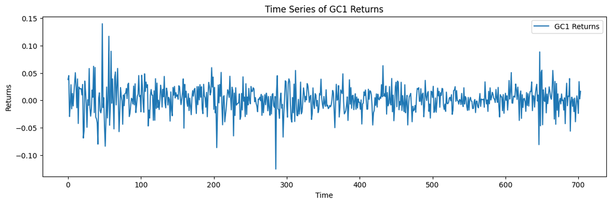

```
CO1 - ADF Statistic: -8.945749180910566
CO1 - p-value: 8.998703458346861e-15
Critical Values:
   1%: -3.439753311961436
   5%: -2.8656896390914217
   10%: -2.568979777013325
The time series for CO1 appears to be stationary (reject the null hypothesis of non-stationarity).
```

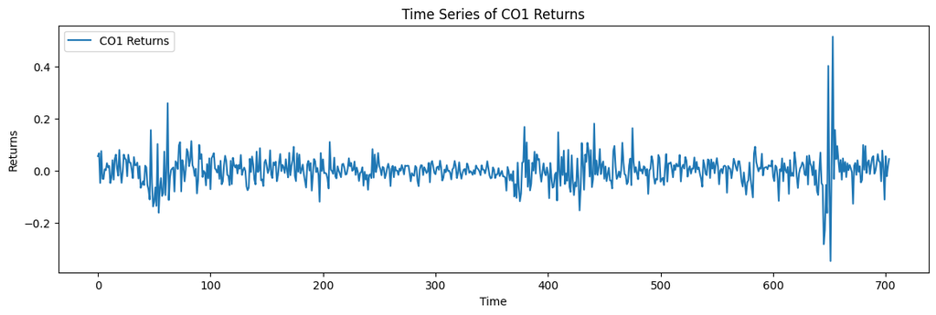

```
ES1 - ADF Statistic: -19.577383849364836
ES1 - p-value: 0.0
Critical Values:
   1%: -3.4396995339981444
   5%: -2.8656659438580796
   10%: -2.5689671530263554
The time series for ES1 appears to be stationary (reject the null hypothesis of non-stationarity).
```

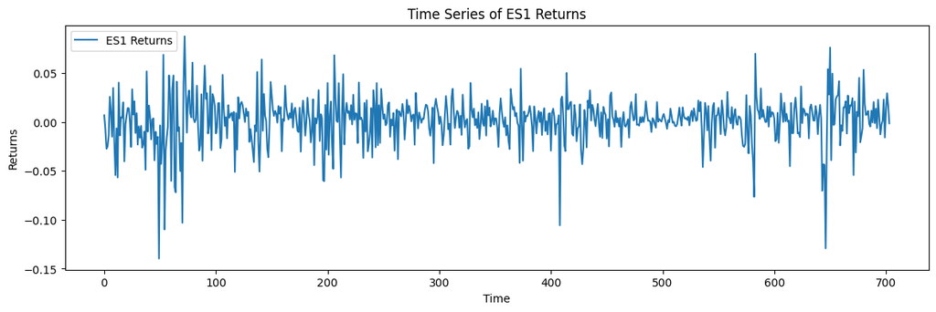

```
VG1 - ADF Statistic: -20.426769679879104
VG1 - p-value: 0.0
Critical Values:
   1%: -3.4396995339981444
   5%: -2.8656659438580796
   10%: -2.5689671530263554
The time series for VG1 appears to be stationary (reject the null hypothesis of non-stationarity).
```

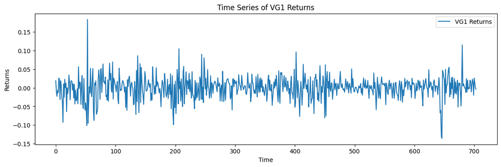

```
NQ1 - ADF Statistic: -26.79960427730783
NQ1 - p-value: 0.0
Critical Values:
   1%: -3.4396861854831964
   5%: -2.865660062273053
   10%: -2.5689640195342456
The time series for NQ1 appears to be stationary (reject the null hypothesis of non-stationarity).
```

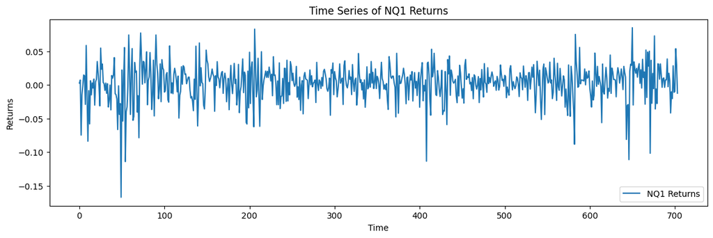

```
LLL1 - ADF Statistic: -4.268403665247594
LLL1 - p-value: 0.0005036315907873357
Critical Values:
   1%: -3.439946506895534
   5%: -2.8657747597081404
   10%: -2.5690251267911495
The time series for LLL1 appears to be stationary (reject the null hypothesis of non-stationarity).
```

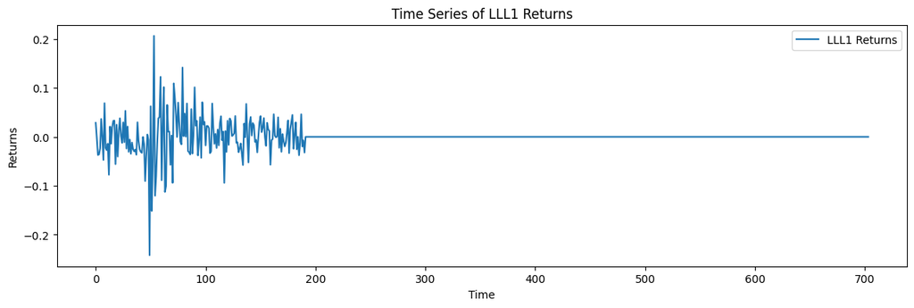

```
TP1 - ADF Statistic: -29.06572339894782
TP1 - p-value: 0.0
Critical Values:
   1%: -3.4396861854831964
   5%: -2.865660062273053
   10%: -2.5689640195342456
The time series for TP1 appears to be stationary (reject the null hypothesis of non-stationarity).
```

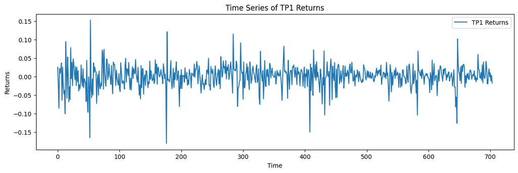

```
DU1 - ADF Statistic: -6.695410753933694
DU1 - p-value: 4.011291264723434e-09
Critical Values:
   1%: -3.439960610754265
   5%: -2.8657809735786244
   10%: -2.5690284373908066
The time series for DU1 appears to be stationary (reject the null hypothesis of non-stationarity).
```

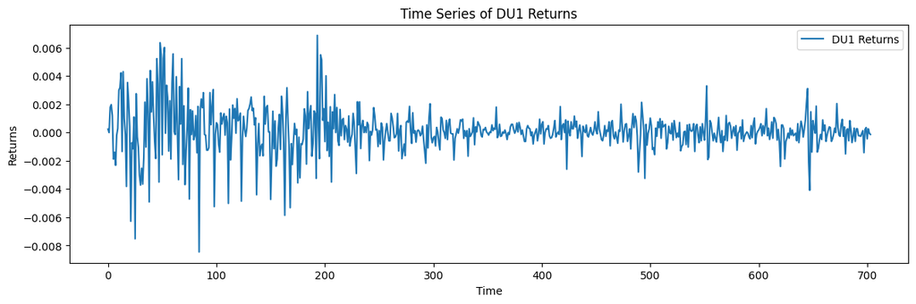

```
TU2 - ADF Statistic: -6.580668822872513
TU2 - p-value: 7.528482061552585e-09
Critical Values:
   1%: -3.4398489271901713
   5%: -2.8657317673059395
   10%: -2.569002221596252
The time series for TU2 appears to be stationary (reject the null hypothesis of non-stationarity).
```

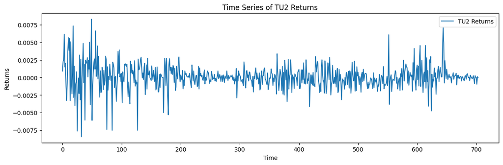

```python
# STATIONARITY STUDY


# Function to check stationarity for each future
def check_stationarity(data):
    for column in data.columns:
        result = adfuller(data[column])
        print(f'{column} - ADF Statistic: {result[0]}')
        print(f'{column} - p-value: {result[1]}')
        print('Critical Values:')
        for key, value in result[4].items():
            print(f'   {key}: {value}')
        if result[1] <= 0.05:
            print(f'The time series for {column} appears to be stationary (reject the null hypothesis of non-stationarity).')
        else:
            print(f'The time series for {column} does not appear to be stationary (fail to reject the null hypothesis of non-stationarity).')
        # Plot the returns to visually inspect stationarity
        plt.figure(figsize=(14, 4))
        plt.plot(data[column], label=f'{column} Returns')
        plt.title(f'Time Series of {column} Returns')
        plt.xlabel('Time')
        plt.ylabel('Returns')
        plt.legend()
        plt.show()

# Check stationarity of futures returns
check_stationarity(returns_futures)
```

--> **All the futures appear to satisfy the Stationarity Property and that's a good thing when working with time series and making replica model**

# Future Selection

We now concatenate our target variable (Monster Index) to the futures, in order to create a new dataset on which developing some models.

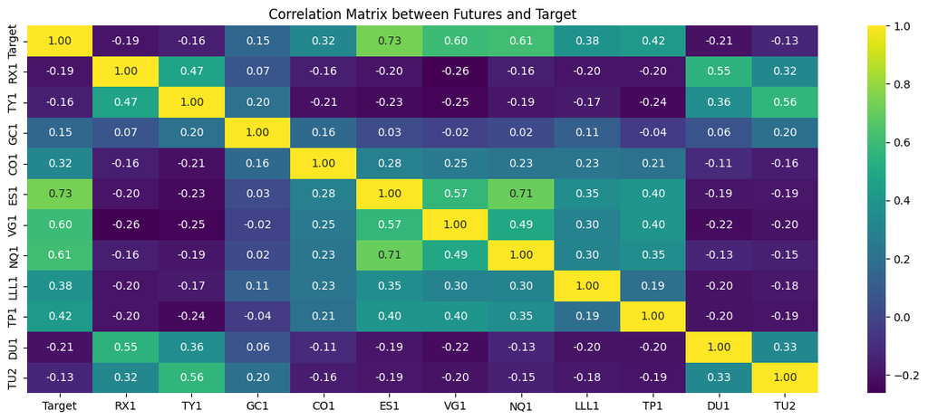

```python
# Concatenate the Target to the Futures
df_concat = pd.concat([returns_MI ,returns_futures], axis=1)

# Compute the Correlation Matrix
correlation_matrix = df_concat.corr(method='kendall')

# Corelation matrix with Heat map
plt.figure(figsize=(16, 6))
sns.heatmap(correlation_matrix, annot=True, cmap='viridis', fmt=".2f")
plt.title('Correlation Matrix between Futures and Target')
plt.show()
```

We then checked for the correlation between Futures and the Target in order to understand wheter to use all the Futures or not. **The idea is to use only the highly correlated Futures**

```python
# Definisci il threshold di correlazione
threshold_up = 0.4
threshold_down = -0.1

# Seleziona le colonne con correlazione superiore ai threshold
highly_correlated_futures = correlation_matrix[
    (correlation_matrix['Target'] > threshold_up) |
    (correlation_matrix['Target'] < threshold_down)
]

# Ottieni solo i nomi delle colonne (future) più correlate con il target
futures_names = highly_correlated_futures.index.tolist()

# Visualizza i nomi delle futures più correlate con il target
print("Futures più correlate con il target (con correlazione maggiore di 0.4 o minore di -0.1):")
print(futures_names)
```

```
Futures più correlate con il target (con correlazione maggiore di 0.4 o minore di -0.1):
['Target', 'RX1', 'TY1', 'ES1', 'VG1', 'NQ1', 'TP1', 'DU1', 'TU2']
```

**We also decided to get rid of the NQ1 because we can see that's highly correlated with ES1 and so in order to reduce the transaction cost we excluded it.**

```python
#We took only the most uncorrelated futures
# Remove 'NQ1' from the list of correlated futures
futures_names_new = [name for name in futures_names[1:] if name != 'NQ1']
returns_futures = returns_futures[futures_names_new]
price_futures_corr = price_futures[futures_names_new]

# Display the updated list of correlated futures
print("Updated futures names after removing 'NQ1':")
print(futures_names_new)
```

```
Updated futures names after removing 'NQ1':
['RX1', 'TY1', 'ES1', 'VG1', 'TP1', 'DU1', 'TU2']
```

**Now that we've explored the dataset and performed future selection, we're ready to proceed with implementing our models**:

- Regression Models
- Kalman Filter
- Recurrent Neural Networks